```r
options(OutDec = ".")  # Asegurar punto decimal en este chunk

# Establecer semilla aleatoria
set.seed(sample(1:10000, 1))

# Función principal de generación de datos
generar_datos_completos <- function() {
  # Ternas pitagóricas expandidas para mayor diversidad
  ternas_pedagogicas <- list(
    c(3, 4, 5),     # Terna básica más conocida
    c(5, 12, 13),   # Segunda terna clásica
    c(8, 15, 17),   # Tercera terna clásica
    c(6, 8, 10),    # Múltiplo de (3,4,5)
    c(9, 12, 15),   # Múltiplo de (3,4,5)
    c(7, 24, 25),   # Cuarta terna clásica
    c(10, 24, 26),  # Múltiplo de (5,12,13)
    c(12, 16, 20),  # Múltiplo de (3,4,5)
    c(15, 20, 25),  # Múltiplo de (3,4,5)
    c(9, 40, 41),   # Quinta terna clásica
    c(11, 60, 61),  # Sexta terna clásica
    c(13, 84, 85),  # Séptima terna clásica
    c(16, 30, 34),  # Múltiplo de (8,15,17)
    c(20, 21, 29),  # Octava terna clásica
    c(18, 24, 30),  # Múltiplo de (3,4,5)
    c(21, 28, 35),  # Múltiplo de (3,4,5)
    c(24, 32, 40),  # Múltiplo de (3,4,5)
    c(27, 36, 45),  # Múltiplo de (3,4,5)
    c(30, 40, 50),  # Múltiplo de (3,4,5)
    c(33, 44, 55)   # Múltiplo de (3,4,5)
  )

  # Seleccionar terna aleatoriamente
  terna_seleccionada <- sample(ternas_pedagogicas, 1)[[1]]

  # === INICIO DE LA MODIFICACIÓN PARA DECIMALES ===

  # 1. Generar un multiplicador decimal aleatorio
  # Con 1 decimal, entre 1.1 y 5.9
  decimales_multiplicador <- 1
  multiplicador <- round(runif(1, 1.1, 5.9), decimales_multiplicador)

  # 2. Aplicar el multiplicador a la terna para obtener valores decimales
  valores_decimales <- terna_seleccionada * multiplicador

  # 3. Determinar el número de decimales para los cálculos
  decimales_calculo <- 1

  # Asignar valores manteniendo la relación pitagórica
  valores_ordenados <- sort(valores_decimales)
  cateto_a <- round(valores_ordenados[1], decimales_calculo)
  cateto_b <- round(valores_ordenados[2], decimales_calculo)
  hipotenusa_c <- round(valores_ordenados[3], decimales_calculo)

  # Verificar que la terna cumple el teorema de Pitágoras con una pequeña tolerancia
  # Esto es CRUCIAL al trabajar con decimales por la precisión de punto flotante
  if (abs((cateto_a^2 + cateto_b^2) - hipotenusa_c^2) > 1e-9) {
    # Si no cumple, usar la terna (3,4,5) con un multiplicador decimal como respaldo
    multiplicador_respaldo <- round(runif(1, 1.1, 2.5), 1)
    cateto_a <- 3 * multiplicador_respaldo
    cateto_b <- 4 * multiplicador_respaldo
    hipotenusa_c <- 5 * multiplicador_respaldo
    decimales_calculo <- 1
  }

  # Validación final: asegurar que la terna es válida dentro de una tolerancia
  stopifnot(abs((cateto_a^2 + cateto_b^2) - hipotenusa_c^2) < 1e-9)
  stopifnot(hipotenusa_c > cateto_a && hipotenusa_c > cateto_b)

  # === FIN DE LA MODIFICACIÓN PARA DECIMALES ===

  # Contextos educativos variados con mayor diversidad
  contextos_educativos <- c(
    "construcción de una rampa de acceso",
    "diseño de una escalera",
    "cálculo de distancias en un plano cartesiano",
    "medición de la diagonal de un rectángulo",
    "navegación marítima entre dos puertos",
    "diseño de un tejado triangular",
    "cálculo de cables de tensión",
    "medición en topografía",
    "diseño de una piscina rectangular",
    "construcción de un puente",
    "cálculo de la altura de un edificio",
    "diseño de una cancha deportiva",
    "medición de terrenos agrícolas",
    "construcción de una torre de comunicación",
    "diseño de un parqueadero",
    "cálculo de distancias en arquitectura",
    "medición de superficies irregulares",
    "diseño de sistemas de riego",
    "construcción de vías de acceso",
    "cálculo de materiales de construcción"
  )

  contexto_seleccionado <- sample(contextos_educativos, 1)

  # Aleatorización de términos matemáticos
  terminos_cateto <- c("cateto", "lado", "base", "altura", "ancho", "largo")
  terminos_hipotenusa <- c("hipotenusa", "diagonal", "distancia", "longitud total", "medida principal")
  terminos_teorema <- c("Teorema de Pitágoras", "fórmula pitagórica", "ecuación pitagórica", "principio pitagórico")

  termino_cateto <- sample(terminos_cateto, 1)
  termino_hipotenusa <- sample(terminos_hipotenusa, 1)
  termino_teorema <- sample(terminos_teorema, 1)

  # Determinar el artículo correcto según el género del término
  if (termino_teorema %in% c("fórmula pitagórica", "ecuación pitagórica")) {
    articulo_teorema <- "la"
  } else {
    articulo_teorema <- "el"
  }

  # Generar datos para los 12 pasos progresivos
  datos_pasos <- list()

  # PASO 1: Identificación de elementos (schoice) - Aleatorización de opciones
  respuesta_correcta_paso1 <- "dos catetos y una hipotenusa"
  distractores_paso1 <- c(
    "tres catetos",
    "una hipotenusa y dos ángulos agudos",
    "tres hipotenusas",
    "dos lados iguales y una base",
    "un ángulo recto y dos lados",
    "tres ángulos agudos",
    "dos hipotenusas y un cateto"
  )
  opciones_seleccionadas_paso1 <- sample(distractores_paso1, 3)
  opciones_paso1_mezcladas <- sample(c(respuesta_correcta_paso1, opciones_seleccionadas_paso1))
  indice_correcto_paso1 <- which(opciones_paso1_mezcladas == respuesta_correcta_paso1)

  preguntas_paso1 <- c(
    "¿Cuáles son los elementos principales de un triángulo rectángulo?",
    "Un triángulo rectángulo se compone fundamentalmente de:",
    "Selecciona los componentes que definen a un triángulo rectángulo.",
    "¿Qué partes clave conforman un triángulo rectángulo?"
  )

  datos_pasos$paso1 <- list(
    pregunta = sample(preguntas_paso1, 1),
    opciones = opciones_paso1_mezcladas,
    correcta = indice_correcto_paso1,
    tipo = "schoice"
  )

  # PASO 2: Reconocimiento del teorema (mchoice) - Aleatorización de opciones
  # Asegurar que siempre haya exactamente 3 correctas y 1 incorrecta
  opciones_correctas_paso2 <- c(
    "Se aplica solo a triángulos rectángulos",
    "La hipotenusa es el lado más largo",
    "Se puede escribir como a² + b² = c²"
  )
  opciones_incorrectas_paso2 <- c(
    "Se aplica a cualquier triángulo",
    "Los catetos son siempre iguales",
    "La suma de los ángulos es 180°",
    "Se puede usar para calcular áreas",
    "Solo funciona con números enteros"
  )
```

```r
  # Seleccionar las 3 correctas y 1 incorrecta
  opciones_paso2_mezcladas <- sample(c(opciones_correctas_paso2, sample(opciones_incorrectas_paso2, 1)))

  # Crear vector de correctas
  correctas_paso2 <- c(
    opciones_paso2_mezcladas[1] %in% opciones_correctas_paso2,
    opciones_paso2_mezcladas[2] %in% opciones_correctas_paso2,
    opciones_paso2_mezcladas[3] %in% opciones_correctas_paso2,
    opciones_paso2_mezcladas[4] %in% opciones_correctas_paso2
  )

  preguntas_paso2 <- c(
    paste("¿Cuáles de las siguientes afirmaciones sobre el", termino_teorema, "son correctas?"),
    paste("Respecto al", termino_teorema, ", indica las proposiciones verdaderas:"),
    paste("Señala todas las afirmaciones válidas acerca del", termino_teorema, "."),
    paste("Elige las características que describen correctamente al", termino_teorema, ".")
  )

  datos_pasos$paso2 <- list(
    pregunta = sample(preguntas_paso2, 1),
    opciones = opciones_paso2_mezcladas,
    correctas = correctas_paso2,
    tipo = "mchoice"
  )

  # PASO 3: Identificación de la hipotenusa (schoice) - Aleatorización de opciones
  respuesta_correcta_paso3 <- formato_estandar(hipotenusa_c, decimales_calculo)
  distractores_paso3 <- c(
    formato_estandar(cateto_a, decimales_calculo),
    formato_estandar(cateto_b, decimales_calculo),
    "No se puede determinar",
    formato_estandar(cateto_a + cateto_b, decimales_calculo),
    formato_estandar(abs(cateto_a - cateto_b), decimales_calculo),
    formato_estandar(cateto_a * cateto_b, decimales_calculo),
    formato_estandar(hipotenusa_c + 1.1, decimales_calculo)
  )
  distractores_paso3 <- unique(distractores_paso3[distractores_paso3 != respuesta_correcta_paso3])
  opciones_seleccionadas_paso3 <- sample(distractores_paso3, 3)
  opciones_paso3_mezcladas <- sample(c(respuesta_correcta_paso3, opciones_seleccionadas_paso3))
  indice_correcto_paso3 <- which(opciones_paso3_mezcladas == respuesta_correcta_paso3)

  preguntas_paso3 <- c(
    paste("En el triángulo con lados", cateto_a, ",", cateto_b, "y", hipotenusa_c, ", ¿cuál es la", termino_hipotenusa, "?"),
    paste("Para un triángulo de lados", cateto_a, ",", cateto_b, "y", hipotenusa_c, ", identifica el valor de la", termino_hipotenusa, "."),
    paste("Considerando los lados", cateto_a, ",", cateto_b, "y", hipotenusa_c, ", ¿qué número corresponde a la", termino_hipotenusa, "?")
  )

  datos_pasos$paso3 <- list(
    pregunta = sample(preguntas_paso3, 1),
    opciones = opciones_paso3_mezcladas,
    correcta = indice_correcto_paso3,
    tipo = "schoice"
  )

  # PASO 4: Cálculo de cuadrados (num)
  preguntas_paso4 <- c(
    paste("Calcula", cateto_a, "²:"),
    paste("Determina el valor de", cateto_a, "elevado al cuadrado."),
    paste("Encuentra el resultado de", cateto_a, "²."),
    paste("¿Cuál es el cuadrado de", cateto_a, "?")
  )

  datos_pasos$paso4 <- list(
    pregunta = sample(preguntas_paso4, 1),
    respuesta = round(cateto_a^2, decimales_calculo * 2),
    tipo = "num",
    tolerancia = 0.5
  )

  # PASO 5: Cálculo de cuadrados (num)
  preguntas_paso5 <- c(
    paste("Calcula", cateto_b, "²:"),
    paste("Determina el valor de", cateto_b, "elevado al cuadrado."),
    paste("Encuentra el resultado de", cateto_b, "²."),
    paste("¿Cuál es el cuadrado de", cateto_b, "?")
  )

  datos_pasos$paso5 <- list(
    pregunta = sample(preguntas_paso5, 1),
    respuesta = round(cateto_b^2, decimales_calculo * 2),
    tipo = "num",
    tolerancia = 0.5
  )

  # PASO 6: Suma de cuadrados (num)
  preguntas_paso6 <- c(
    paste("Calcula", cateto_a, "² +", cateto_b, "²:"),
    paste("Suma los cuadrados de los catetos:", cateto_a, "² +", cateto_b, "²."),
    paste("¿Cuál es el resultado de la suma", cateto_a, "² +", cateto_b, "²?"),
    paste("Determina el valor total de", cateto_a, "² más", cateto_b, "².")
  )

  datos_pasos$paso6 <- list(
    pregunta = sample(preguntas_paso6, 1),
    respuesta = round(cateto_a^2 + cateto_b^2, decimales_calculo * 2),
    tipo = "num",
    tolerancia = 0.5
  )

  # PASO 7: Verificación del teorema (schoice) - Aleatorización de opciones
  respuesta_correcta_paso7 <- "Sí"
  distractores_paso7 <- c(
    "No",
    "No se puede determinar",
    "Depende del contexto",
    "Solo si los catetos son iguales",
    "Solo con números enteros",
    "Solo en triángulos equiláteros",
    "Solo si la hipotenusa es par"
  )
  opciones_seleccionadas_paso7 <- sample(distractores_paso7, 3)
  opciones_paso7_mezcladas <- sample(c(respuesta_correcta_paso7, opciones_seleccionadas_paso7))
  indice_correcto_paso7 <- which(opciones_paso7_mezcladas == respuesta_correcta_paso7)

  preguntas_paso7 <- c(
    paste("¿Es cierto que", cateto_a, "² +", cateto_b, "² =", hipotenusa_c, "²?"),
    paste("Verifica si la igualdad", cateto_a, "² +", cateto_b, "² =", hipotenusa_c, "² es correcta."),
    "¿Se cumple que la suma de los cuadrados de los catetos es igual al cuadrado de la hipotenusa en este caso?"
  )

  datos_pasos$paso7 <- list(
    pregunta = sample(preguntas_paso7, 1),
    opciones = opciones_paso7_mezcladas,
    correcta = indice_correcto_paso7,
    tipo = "schoice"
  )

  # PASO 8: Aplicación inversa - encontrar cateto (num)
  # Crear un problema donde se conoce un cateto y la hipotenusa
  cateto_conocido <- cateto_a
  cateto_desconocido <- cateto_b

  preguntas_paso8 <- c(
    paste("Si un cateto mide", cateto_conocido, "y la hipotenusa mide", hipotenusa_c, ", ¿cuánto mide el otro cateto?"),
    paste("Dado un cateto de", cateto_conocido, "y una hipotenusa de", hipotenusa_c, ", calcula la longitud del cateto faltante."),
    paste("En un triángulo rectángulo, la hipotenusa es", hipotenusa_c, "y uno de los catetos es", cateto_conocido, ". Halla el otro cateto.")
  )

  datos_pasos$paso8 <- list(
    pregunta = sample(preguntas_paso8, 1),
    respuesta = cateto_desconocido,
    tipo = "num",
    tolerancia = 0.5
  )

  # PASO 9: Verificación de cálculo (schoice) - Aleatorización de opciones
  respuesta_correcta_paso9 <- paste("Calcular √(", hipotenusa_c, "² -", cateto_conocido, "²)")
  distractores_paso9 <- c(
    paste("Calcular", hipotenusa_c, "+", cateto_conocido),
    paste("Calcular", hipotenusa_c, "×", cateto_conocido),
    paste("Calcular", hipotenusa_c, "÷", cateto_conocido),
    paste("Calcular", hipotenusa_c, "² +", cateto_conocido, "²"),
    paste("Calcular √(", hipotenusa_c, "² +", cateto_conocido, "²)"),
    paste("Calcular", hipotenusa_c, "-", cateto_conocido),
    paste("Calcular √(", hipotenusa_c, "×", cateto_conocido, ")")
  )
  opciones_seleccionadas_paso9 <- sample(distractores_paso9, 3)
  opciones_paso9_mezcladas <- sample(c(respuesta_correcta_paso9, opciones_seleccionadas_paso9))
  indice_correcto_paso9 <- which(opciones_paso9_mezcladas == respuesta_correcta_paso9)
```

```r
  preguntas_paso9 <- c(
    paste("Para verificar que", cateto_desconocido, "es correcto, ¿qué operación debemos realizar?"),
    paste("¿Cuál es el cálculo correcto para encontrar un cateto si la hipotenusa es", hipotenusa_c, "y el otro cateto es", cateto_conocido, "?"),
    "Selecciona la fórmula que permite hallar el cateto faltante a partir de la hipotenusa y un cateto conocido."
  )

  datos_pasos$paso9 <- list(
    pregunta = sample(preguntas_paso9, 1),
    opciones = opciones_paso9_mezcladas,
    correcta = indice_correcto_paso9,
    tipo = "schoice"
  )

  # PASO 10: Aplicación contextual (mchoice) - Aleatorización de opciones
  # Asegurar que siempre haya exactamente 3 correctas y 1 incorrecta
  opciones_correctas_paso10 <- c(
    "Calcular distancias directas",
    "Determinar ángulos rectos",
    "Verificar medidas"
  )
  opciones_incorrectas_paso10 <- c(
    "Calcular áreas de círculos",
    "Calcular perímetros de rectángulos",
    "Determinar volúmenes de cilindros",
    "Calcular superficies de esferas",
    "Verificar proporciones",
    "Calcular diagonales de cuadrados",
    "Determinar alturas de triángulos"
  )

  # Seleccionar las 3 correctas y 1 incorrecta
  opciones_paso10_mezcladas <- sample(c(opciones_correctas_paso10, sample(opciones_incorrectas_paso10, 1)))

  # Crear vector de correctas
  correctas_paso10 <- c(
    opciones_paso10_mezcladas[1] %in% opciones_correctas_paso10,
    opciones_paso10_mezcladas[2] %in% opciones_correctas_paso10,
    opciones_paso10_mezcladas[3] %in% opciones_correctas_paso10,
    opciones_paso10_mezcladas[4] %in% opciones_correctas_paso10
  )

  preguntas_paso10 <- c(
    paste("En el contexto de", contexto_seleccionado, ", ¿cuáles son aplicaciones válidas del", termino_teorema, "?"),
    paste("Considerando la situación sobre", contexto_seleccionado, ", ¿para qué sirve aplicar el", termino_teorema, "?"),
    paste("¿En cuál de estos escenarios es útil el", termino_teorema, "dentro del problema de", contexto_seleccionado, "?")
  )

  datos_pasos$paso10 <- list(
    pregunta = sample(preguntas_paso10, 1),
    opciones = opciones_paso10_mezcladas,
    correctas = correctas_paso10,
    tipo = "mchoice"
  )

  # PASO 11: Análisis de error común (schoice) - Aleatorización de opciones
  error_comun <- cateto_a + cateto_b  # Error: suma en lugar de teorema
  respuesta_correcta_paso11 <- "Sumó los catetos en lugar de usar el teorema"
  distractores_paso11 <- c(
    "No calculó correctamente la suma",
    "Usó la fórmula incorrecta del área",
    "No hay error en el cálculo",
    "Confundió la hipotenusa con el perímetro",
    "Aplicó mal la fórmula de la raíz cuadrada",
    "No consideró que es un triángulo rectángulo",
    "Usó la fórmula del teorema de Tales"
  )
  opciones_seleccionadas_paso11 <- sample(distractores_paso11, 3)
  opciones_paso11_mezcladas <- sample(c(respuesta_correcta_paso11, opciones_seleccionadas_paso11))
  indice_correcto_paso11 <- which(opciones_paso11_mezcladas == respuesta_correcta_paso11)

  preguntas_paso11 <- c(
    paste("Un estudiante calcula la", termino_hipotenusa, "como", cateto_a, "+", cateto_b, "=", error_comun, ". ¿Cuál es el error?"),
    paste("Al intentar hallar la", termino_hipotenusa, ", un alumno obtiene", error_comun, "sumando", cateto_a, "y", cateto_b, ". ¿Qué hizo mal?"),
    paste("Si el resultado para la", termino_hipotenusa, "fue", error_comun, "basado en la operación", cateto_a, "+", cateto_b, ", identifica el error conceptual.")
  )

  datos_pasos$paso11 <- list(
    pregunta = sample(preguntas_paso11, 1),
    opciones = opciones_paso11_mezcladas,
    correcta = indice_correcto_paso11,
    tipo = "schoice"
  )

  # PASO 12: Síntesis y transferencia (num)
  # Problema de transferencia con nueva terna y multiplicador decimal
  nueva_terna <- sample(list(c(9, 12, 15), c(12, 16, 20), c(15, 20, 25)), 1)[[1]]
  multiplicador_nuevo <- round(runif(1, 1.1, 3.5), 1)
  nuevo_cateto_a <- round(nueva_terna[1] * multiplicador_nuevo, 1)
  nuevo_cateto_b <- round(nueva_terna[2] * multiplicador_nuevo, 1)
  nueva_hipotenusa <- round(nueva_terna[3] * multiplicador_nuevo, 1)

  preguntas_paso12 <- c(
    paste("Problema de transferencia: Si los catetos de un triángulo rectángulo miden", nuevo_cateto_a, "y", nuevo_cateto_b, ", ¿cuál es la longitud de la hipotenusa?"),
    paste("Aplica lo aprendido: un triángulo rectángulo tiene catetos de", nuevo_cateto_a, "y", nuevo_cateto_b, ". Calcula su hipotenusa."),
    paste("Para finalizar, halla la hipotenusa de un triángulo cuyos catetos son", nuevo_cateto_a, "y", nuevo_cateto_b, ".")
  )

  datos_pasos$paso12 <- list(
    pregunta = sample(preguntas_paso12, 1),
    respuesta = nueva_hipotenusa,
    tipo = "num",
    tolerancia = 0.5
  )

  return(list(
    cateto_a = cateto_a,
    cateto_b = cateto_b,
    hipotenusa_c = hipotenusa_c,
    decimales_calculo = decimales_calculo, # <-- AÑADIR ESTA LÍNEA
    contexto = contexto_seleccionado,
    termino_cateto = termino_cateto,
    termino_hipotenusa = termino_hipotenusa,
    termino_teorema = termino_teorema,
    articulo_teorema = articulo_teorema,
    pasos = datos_pasos
  ))
}

# Generar datos del ejercicio
datos <- generar_datos_completos()

# Detectar formato de salida para ajustes posteriores
formatos_moodle <- c("exams2moodle", "exams2qti12", "exams2qti21", "exams2openolat")
es_moodle <- (match_exams_call() %in% formatos_moodle)

# Validaciones de coherencia matemática
test_that("Validación del Teorema de Pitágoras", {
  # Verificar que la terna seleccionada cumple el teorema
  # Aumentamos la tolerancia para cálculos con punto flotante
  expect_true(abs(datos$cateto_a^2 + datos$cateto_b^2 - datos$hipotenusa_c^2) < 1e-9)
})
```

Test passed 🎉

```r
test_that("Validación de valores positivos", {
  expect_true(datos$cateto_a > 0)
  expect_true(datos$cateto_b > 0)
  expect_true(datos$hipotenusa_c > 0)
})
```

Test passed 🎉

```r
test_that("Validación de la hipotenusa como lado más largo", {
  expect_true(datos$hipotenusa_c > datos$cateto_a)
  expect_true(datos$hipotenusa_c > datos$cateto_b)
})
```

Test passed 🎉

```r
test_that("Validación de respuestas numéricas", {
  # Aumentamos la tolerancia para cálculos con punto flotante
  expect_true(abs(datos$pasos$paso4$respuesta - datos$cateto_a^2) < 0.1)
  expect_true(abs(datos$pasos$paso5$respuesta - datos$cateto_b^2) < 0.1)
  expect_true(abs(datos$pasos$paso6$respuesta - (datos$cateto_a^2 + datos$cateto_b^2)) < 0.1)
})
```

Test passed 😀

# Question

## Entrenamiento Completo: fórmula pitagórica

**Contexto:** En el ámbito de construcción de un puente, necesitas aplicar la fórmula pitagórica de manera sistemática y comprensiva.

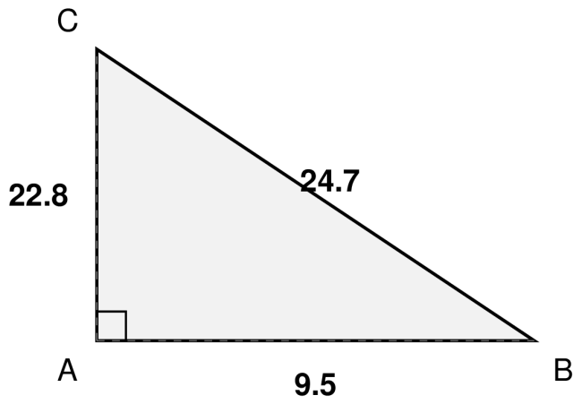

Completa los siguientes **12 pasos progresivos** para demostrar tu comprensión completa del Teorema de Pitágoras:

### **FASE I: Comprensión Conceptual**

**Paso 1.** Un triángulo rectángulo se compone fundamentalmente de: ##ANSWER1##

**Paso 2.** Señala todas las afirmaciones válidas acerca del fórmula pitagórica . ##ANSWER2##

**Paso 3.** Considerando los lados 9.5 , 22.8 y 24.7 , ¿qué número corresponde a la distancia ? ##ANSWER3##

### **FASE II: Aplicación Numérica**

**Paso 4.** Determina el valor de 9.5 elevado al cuadrado. ##ANSWER4##

**Paso 5.** Calcula 22.8 ²: ##ANSWER5##

**Paso 6.** Determina el valor total de 9.5 ² más 22.8 ². ##ANSWER6##

### **FASE III: Verificación y Análisis**

**Paso 7.** ¿Se cumple que la suma de los cuadrados de los catetos es igual al cuadrado de la hipotenusa en este caso? ##ANSWER7##

**Paso 8.** En un triángulo rectángulo, la hipotenusa es 24.7 y uno de los catetos es 9.5 . Halla el otro cateto. ##ANSWER8##

**Paso 9.** ¿Cuál es el cálculo correcto para encontrar un cateto si la hipotenusa es 24.7 y el otro cateto es 9.5 ? ##ANSWER9##

### **FASE IV: Transferencia y Síntesis**

**Paso 10.** En el contexto de construcción de un puente , ¿cuáles son aplicaciones válidas del fórmula pitagórica ? ##ANSWER10##

**Paso 11.** Un estudiante calcula la distancia como 9.5 + 22.8 = 32.3 . ¿Cuál es el error? ##ANSWER11##

**Paso 12.** Problema de transferencia: Si los catetos de un triángulo rectángulo miden 31.2 y 41.6 , ¿cuál es la longitud de la hipotenusa? ##ANSWER12##

## Answerlist

- dos catetos y una hipotenusa
- tres catetos
- tres ángulos agudos
- una hipotenusa y dos ángulos agudos
- Se aplica a cualquier triángulo
- Se puede escribir como a² + b² = c²
- Se aplica solo a triángulos rectángulos
- La hipotenusa es el lado más largo
- 24.7
- 9.5
- 32.3
- 216.6
- Solo si la hipotenusa es par
- No se puede determinar
- Sí
- Solo si los catetos son iguales
- Calcular 24.7 ÷ 9.5
- Calcular √( 24.7 × 9.5 )
- Calcular √( 24.7 ² + 9.5 ²)
- Calcular √( 24.7 ² - 9.5 ²)
- Determinar ángulos rectos
- Verificar medidas
- Determinar volúmenes de cilindros
- Calcular distancias directas
- Confundió la hipotenusa con el perímetro
- Aplicó mal la fórmula de la raíz cuadrada
- No consideró que es un triángulo rectángulo
- Sumó los catetos en lugar de usar el teorema

# Solution

## Solución Completa del Entrenamiento: fórmula pitagórica

Este ejercicio pedagógico evalúa la comprensión integral de la fórmula pitagórica a través de 12 pasos progresivos que abarcan desde conceptos básicos hasta aplicaciones avanzadas.

### **FASE I: Comprensión Conceptual**

**Paso 2:** Las afirmaciones correctas sobre la fórmula pitagórica son:

- Sí: Se aplica solo a triángulos rectángulos
- Sí: La hipotenusa es el lado más largo
- Sí: Se puede escribir como a² + b² = c²
- NO: NO se aplica a cualquier triángulo (solo a rectángulos)

**Paso 3:** En el triángulo con lados 9.5, 22.8 y 24.7, la hipotenusa es **24.7** porque es el lado más largo.

### **FASE II: Aplicación Numérica**

**Paso 4:** 9.5² = **90.25**

**Paso 5:** 22.8² = **519.84**

**Paso 6:** 9.5² + 22.8² = 90.25 + 519.84 = **610.09**

### **FASE III: Verificación y Análisis**

**Paso 8:** Si un cateto mide 9.5 y la hipotenusa mide 24.7, el otro cateto mide **22.8**. Cálculo: √(24.7² - 9.5²) = √(610.09 - 90.25) = √519.84 es aproximadamente 22.8

**Paso 9:** Para verificar que 22.8 es correcto, debemos **calcular √(24.7² - 9.5²)**, que es la aplicación directa de la fórmula pitagórica despejando un cateto.

### **FASE IV: Transferencia y Síntesis**

**Paso 11:** El error del estudiante es que **sumó los catetos en lugar de usar la fórmula pitagórica**. La suma 9.5 + 22.8 = 32.3 no da la hipotenusa correcta (24.7).

**Paso 12:** Para el problema de transferencia con catetos, la hipotenusa es **52.0**.

### Explicaciones Detalladas por Paso

**Paso 1:** Respuesta correcta: dos catetos y una hipotenusa

**Paso 2:** Respuestas correctas: Se puede escribir como a² + b² = c², Se aplica solo a triángulos rectángulos, La hipotenusa es el lado más largo

**Paso 3:** Respuesta correcta: 24.7

**Paso 4:** Respuesta numérica: 90.25

**Paso 5:** Respuesta numérica: 519.84

**Paso 6:** Respuesta numérica: 610.09

**Paso 7:** Respuesta correcta: Sí

**Paso 8:** Respuesta numérica: 22.80

**Paso 9:** Respuesta correcta: Calcular √( 24.7 ² - 9.5 ²)

**Paso 10:** Respuestas correctas: Determinar ángulos rectos, Verificar medidas, Calcular distancias directas

**Paso 11:** Respuesta correcta: Sumó los catetos en lugar de usar el teorema

**Paso 12:** Respuesta numérica: 52.00

### Evaluación Pedagógica

Este ejercicio evalúa:

- **Comprensión conceptual** (Pasos 1-3): Identificación de elementos y principios
- **Habilidades de cálculo** (Pasos 4-6): Operaciones aritméticas básicas
- **Aplicación del teorema** (Pasos 7-9): Uso directo e inverso de la fórmula
- **Transferencia de conocimiento** (Pasos 10-12): Aplicación a nuevos contextos

La progresión de dificultad asegura que los estudiantes desarrollen una comprensión profunda y duradera de la fórmula pitagórica, previniendo respuestas mecánicas y promoviendo el razonamiento matemático.

# Meta-information

exname: teorema_pitagoras_entrenamiento_completo_cloze_geometrico_metrico_formulacion_ejecucion_n2 extype: cloze exsolution: 1000|0111|1000|90.25|519.84|610.09|0010|22.8|0001|1101|0001|52 exclozetype: schoice|mchoice|schoice|num|num|num|schoice|num|schoice|mchoice|schoice|num extol: 0|0|0|0.5|0.5|0.5|0|0.5|0|0|0|0.5 exshuffle: TRUE exsection: Geometria|Teorema de Pitagoras|Entrenamiento Completo exversion: 1 exdate: 2025-09-29 exauthor: Sistema de Generacion ICFES exemail: alvaroangelm@iepedacitodecielo.edu.co exinstitution: ICFES exlanguage: es excomment: Ejercicio de entrenamiento completo del Teorema de Pitagoras con 12 pasos progresivos que incluyen comprension conceptual, aplicacion numerica, verificacion y transferencia de conocimiento. Optimizado para generar mas de 300 variantes unicas con aleatorizacion avanzada de contextos, terminos matematicos y opciones de respuesta.